# Tvyal Newsletter

Aghasi Tavadyan

2024-02-02

*English summary below.*

Հարգելի գործընկեր,

Հուսով եմ լավ եք: Ներկայացնում եմ այս շաբաթվա վերլուծությունները և աշխատանքները.

1. 🍇🚀 Wildberries-ը աճել է 35 անգամ 1 տարվա ընթացքում
2. English summary

## 1. 🍇🚀 Wildberries-ը աճել է 35 անգամ 1 տարվա ընթացքում

2023 թվականի 4-րդ եռամսյակի կտրվածքով Wildberries ընկերությունը 4-րդ ամենախոշոր հարկատուն է, որի հարկերը մեկ տարվա մեջ աճել են 35 անգամ։

Նույն միտումը նկատվում է Մոբայլ Սենթր և Վեստա ընկերությունների մոտ, որոնց հարկային մուտքերը մեկ տարվա ընթացքում աճել են համապատասխանաբար 2,6 և 3,9 անգամ։ Այս ընկերությունները նույնպես 2023 թվականի ամենախոշոր 5 հարկատուների ցանկում են։

Անդրադառնանք յուրաքանչյուր ընկերությանը։

### Վայլդբերիս

Wildberries-ը 2023 թվականի 4-րդ եռամսյակի կտրվածքով դարձել է 4-րդ խոշոր հարկատուն՝ վճարելով 13,9 մլրդ դրամի հարկ։ 2023 թվականի 4-րդ եռամսյակում իրենից առաջ են միայն «Գրանդ Տոբակո» (24,3 մլրդ դրամ), «Զանգեզուրի պղնձամոլիբդենային կոմբինատ» (18,5 մլրդ դրամ) և «Մոբայլ սենթր արտ» (16,0 մլրդ դրամ) ընկերությունները։

Նշենք, որ ընդհանուր 2023 թվականի համար Wildberries-ը 6-րդ տեղում է՝ վճարելով 26,5 մլրդ դրամի հարկ, որի կեսից ավելին վճարվել է վերջին եռամսյակում։

Դեռևս երկու տարի առաջ Wildberries ընկերությունը Հայաստանի խոշորագույն հարկատուների ցանկում 400-րդ հորիզոնականից էլ ցածր էր։ 2022 թվականին այս կազմակերպությունը վճարել է 0,8 մլրդ դրամի հարկ՝ մեկ տարում աճելով 35 անգամ։

Նման արագ, էքսպոնենցիալ աճի պայմաններում Wildberries-ը հաջորդ տարի կարող է դառնալ ամենախոշոր հարկատուն: Wildberries-ի հարկերի 97,5 տոկոսը ԱԱՀ է, մաքսատուրքեր չի վճարել, քանի որ Հայաստանը ԵԱՏՄ անդամ երկիր է։

**Աղյուսակ 1.** Wildberries, 4-րդ խոշոր հարկատուն 2023 թվականի 4-րդ եռամսյակում

[figure not shown]

### Մոբայլ Սենթր

Մոբայլ Սենթր կազմակերպությունը հարկերի 95,5 տոկոսը Ավելացված արժեքի հարկն է, որը համազոր է Wildberries ընկերությանը: Ընդ որում՝ 2023-ին ընդհանուր հարկային վճարները 2022 թվականի համեմատ աճել են 2,6 անգամ (17,6 մլրդ դրամից մինչև 46,1 մլրդ դրամ), իսկ 2021-ի համեմատ՝ 10,4 անգամ։

2023 թվականի հունվարից մինչև նոյեմբեր Հայաստանն արտահանել է 442,3 մլն դոլարին համարժեք սմարթֆոններ, որոնք հիմնականում ներմուծվել են Վիետնամից և վերաարտահանվել Ռուսաստան։ Միայն սմարթֆոնների արտահանումը կազմել է ընդհանուր արտահանման 6 տոկոսը։

**Գծապատկեր 2.** Mobile Center, 3-րդ խոշոր հարկատուն 2023 թվականի 4-րդ եռամսյակում

[figure not shown]

Եթե մինչև 2021 թվականը ալկոհոլային խմիչքները՝ հայկական կոնյակի գլխավորությամբ, զբաղեցնում էին Ռուսաստան արտահանման առաջին տեղը, ապա այժմ դրանք հեռախոսներն ու սպառողական էլեկտրոտեխնիկան է։

**Գծապատկեր 3.** Սմարթֆոնների արտահանումը և ներմուծումը Հայաստան

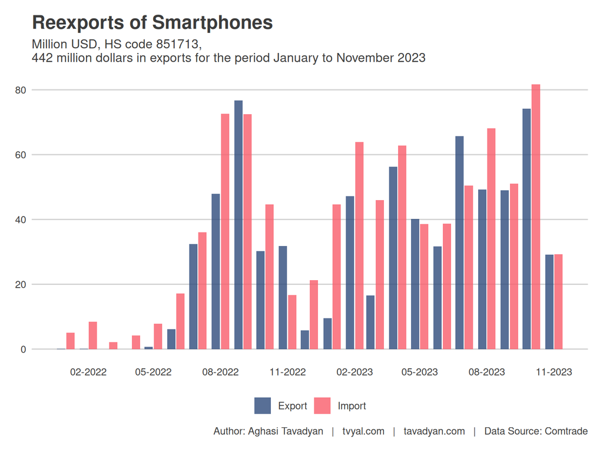

> Նշենք որ մեր կողմից ստեղծվել է օնլայն հարթակ, որը գնահատում և կանխատեսում է Հայաստանի արտահանումը տարբեր տարածաշրջաններով և ապրանքներով։ Հարթակում տրված է ավելի քան 2000 կանխատեսում։

> [Ավելի քան 2000 կանխատեսում. Հայաստանի արտահանումը](https://tavad.shinyapps.io/exports_forecast/):

### “ՓՐԻԹԻ ՈՒԵՅ” ՍՊԸ (Վեստա)

Ի տարբերություն Wildberries-ի և Mobile Center-ի, Pretty Way (Vesta) ընկերությունը իր հարկային եկամուտների ընդամենը 62,1 տոկոսն է ստացել ավելացված արժեքի հարկից: Հատկանշական է, որ ի տարբերություն վերոնշյալ ընկերությունների, Pretty Way-ը վճարում է զգալի մաքսավճարներ։ 2023 թվականին ընդհանուր հարկային եկամուտները կազմել են 33,3 մլրդ դրամ, մաքսատուրքերը կազմել են 29,5 մլրդ դրամ կամ 88,6 տոկոս։ Մաքսատուրքերը սովորաբար հաշվարկվում են մաքսային արժեքի հիման վրա՝ ներառելով ներմուծվող ապրանքների արժեքը բոլոր կիրառելի հարկերի հետ միասին, ներառյալ ավելացված արժեքի հարկը: Ուստի մաքսային եկամուտների մի մասը ներառում է ներմուծվող ապրանքների ԱԱՀ-ն։

Դրա մասին է վկայում նաև այն, որ 2023 թվականին նախապատրաստված բյուջեից Pretty Way-ին վերադարձվել է անուղղակի հարկերից 17,7 մլրդ դրամ (53 տոկոս): Նման վերադարձները կատարվում են հիմնականում մի պետությունից մյուս պետություն ապրանքի տեղափոխման հետ կապված անուղղակի հարկերի վերադարձից։

Pretty Way ընկերության հարկային եկամուտները 2023 թվականին 2022 թվականի համեմատ աճել են 3,9 անգամ (8,5 մլրդ դրամից մինչև 33,3 մլրդ դրամ), իսկ 2021 թվականի համեմատ՝ 16,5 անգամ։ Հարկ է նշել, որ կենցաղային տեխնիկան (համակարգիչներ, մոնիտորներ, հեռուստացույցներ, տպիչներ) կազմում են ՀՀ արտահանման զգալի տոկոսը։ 2023 թվականին Էլեկտրական սարքավորումները (արտաքին տնտեսական գործունեության `85` երկնիշ ծածկագր) կազմել են արտահանման 13 տոկոսը։

**Գծապատկեր 4.** Vesta-ն (Pretty Way), 5-րդ խոշոր հարկատուն 2023 թվականի 4-րդ եռամսյակում

[figure not shown]

## 2. English Summary

**🍇🚀 Wildberries grew 35 times in 1 year**

## Այս վերլուծությունը առկա է նաև [մեր կայքէջում](https://www.tvyal.com/newsletter/2024/2024_02_02), այս վերլուծության կոդը և տվյալները դրված են նաև [Github-ում](https://github.com/tavad/tvyal_newsletter)։

Եթե հնարավոր է, խնդրում եմ այս նյութը ուղարկել նաև այն մարդկանց, ում այն կարծում եք կարող է հետաքրքրել:

Սպասեք հաջորդ հաղորդագրությանը հաջորդ ուրբաթ օրը:

Հարգանքներով,  
Աղասի Թավադյան  
02.02.2024  
[tvyal.com](https://www.tvyal.com/)  
[tavadyan.com](https://www.tavadyan.com/)

[Was this email forwarded to you? Subscribe here.](https://www.tvyal.com/subscribe)

[Բաժանորդագրվեք](https://www.tvyal.com/subscribe)

**Ուշադրություն. Ձեր էլ.փոստը մեյլիսթի մեջ է, որի միջոցով ես կիսվում եմ շաբաթական նյութեր, որոնք հիմնականում ներկայացնում են Հայաստանի տնտեսությանը: Նյութերը ներառում են գծապատկերներ, [տվյալների բազաներ](https://github.com/tavad/tvyal_newsletter), տեսանյութեր, հոդվածներ, [առցանց վահանակներ](https://www.tvyal.com/projects), տնտեսական գործիքներ, կանխատեսումներ և հաշվետվություններ: Եթե ցանկանում եք չեղարկել բաժանորդագրությունը, խնդրում եմ տեղեկացրեք ինձ, և ես կհեռացնեմ ձեր էլ. փոստը ցուցակից: Գրեք նաև եթե ունեք մենկնաբանություններ:**

**Important! Your email is part of the mailing list where I share weekly materials primarily focused on the Armenian economy. These materials encompass charts, [databases](https://github.com/tavad/tvyal_newsletter), videos, articles, [online dashboards](https://www.tvyal.com/projects), economic tools, forecasts, and reports. If you wish to unsubscribe, please let me know, and I will remove your email from the list. Please share your comments as well․**